# Final Exam - IE 360 Spring 2021

Osman Oguz Nuhoglu

## INTRODUCTION

People depend on electricity and therefore electricity production business is a very important business today. It requires challenging practices such as forecasting the next periods consumption so that a price for electricity can be determined. This way, firms can provide the best offer to produce the electricity.

This study aims to make a forecast for a specified time period. After analyzing the data, we try several models and choose the best one. That model will make forecasts for the specified test period.

Variables are self explanatory and can be seen in the structure of the data below.

## ANALYSIS

```r
data=fread("mcp_with_variables.csv", header=TRUE)
str(data)
```

```
## Classes 'data.table' and 'data.frame':   53112 obs. of  19 variables:
##  $ date       : IDate, format: "2015-06-01" "2015-06-01" ...
##  $ hour       : int  0 1 2 3 4 5 6 7 8 9 ...
##  $ mcp_try    : num  103.8 88 49.1 33.8 28.9 ...
##  $ mcp_dollars: num  39 33.1 18.4 12.7 10.9 ...
##  $ mcp_euro   : num  35.61 30.19 16.83 11.59 9.93 ...
##  $ load_plan  : int  25600 23900 23000 22600 22500 21900 22300 25000 30200 33200 ...
##  $ total_prod : num  20657 20292 19666 19650 19664 ...
##  $ natural_gas: num  6198 6391 6403 6388 6300 ...
##  $ wind       : num  169 166 172 182 189 ...
##  $ lignite    : num  2799 2799 2799 2799 2799 ...
##  $ black_coal : num  742 630 630 630 630 630 630 742 742 714 ...
##  $ import_coal: num  3901 3708 3179 3112 3113 ...
##  $ fuel_oil   : num  417 417 417 417 417 417 417 417 462 462 ...
##  $ geothermal : num  74.8 74.8 74.8 74.8 74.8 74.8 74.8 74.8 74.8 74.8 ...
##  $ dam        : num  5057 4833 4726 4824 4798 ...
##  $ naphta     : num  0 0 0 0 0 0 0 0 0 0 ...
##  $ biomass    : num  0 0 0 0 0 0 0 0 0 0 ...
##  $ river      : num  1159 1134 1125 1082 1203 ...
##  $ other      : num  140 140 140 140 140 140 140 140 140 140 ...
##  - attr(*, ".internal.selfref")=<externalptr>
```

```r
hours<-c("00:00","01:00","02:00","03:00","04:00","05:00","06:00","07:00","08:00","09:00","10:00",
       "11:00","12:00","13:00","14:00","15:00","16:00","17:00","18:00","19:00","20:00","21:00",
       "22:00","23:00")
data[,hour:=hours[hour+1]]
data[,time:=paste(date,hour)]
data[,time:=as.POSIXct(time, format = "%Y-%m-%d %H:%M", tz = "Europe/Istanbul")]
data[,c("date","hour"):=NULL]
```

There is no need for further manipulation. We can check how the time series of different currencies look.

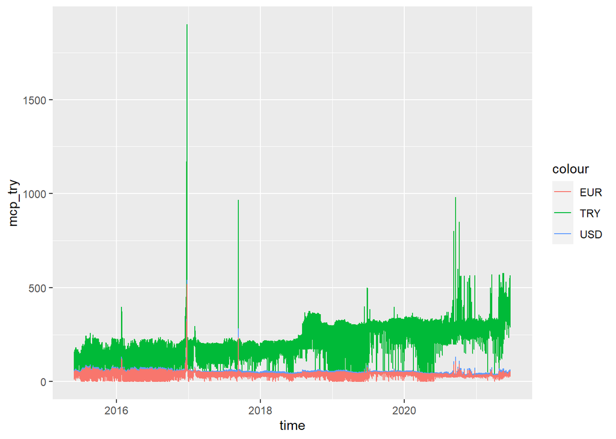

```r
ggplot(data, aes(x=time)) +
  geom_line(aes(y=mcp_try, col="TRY")) +
  geom_line(aes(y=mcp_dollars, col="USD")) +
  geom_line(aes(y=mcp_euro, col="EUR"))
```

TRY does not seem to be stable. This could be said even without looking at the plot. TRY has been experiencing a high inflation and depreciation for a long period of time.

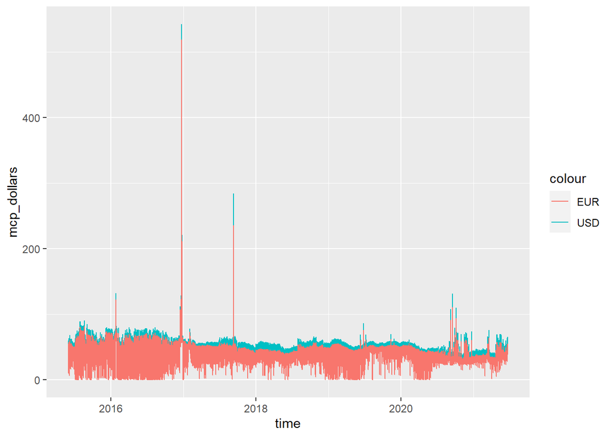

```r
ggplot(data, aes(x=time)) +
  geom_line(aes(y=mcp_dollars, col="USD")) +
    geom_line(aes(y=mcp_euro, col="EUR"))
```

EUR and USD look very similar, any one can be used for forecasting purposes. I choose USD since it is more popular than EUR.

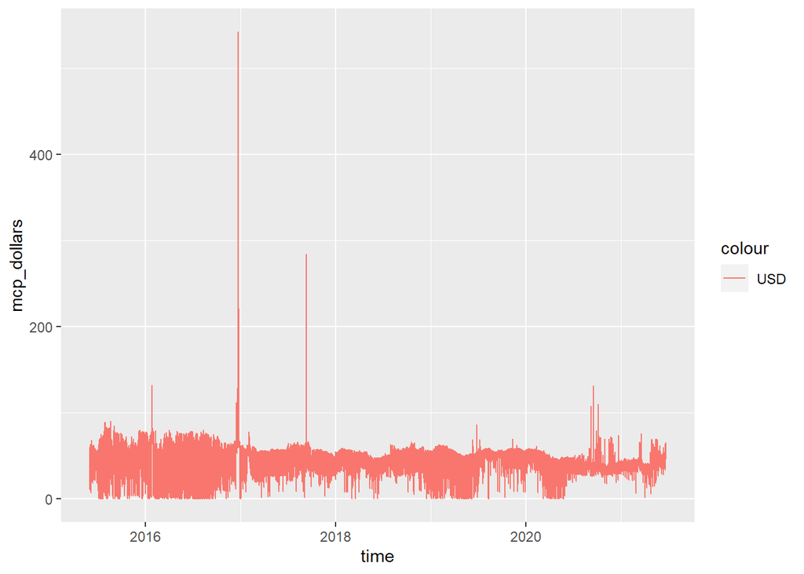

```r
ggplot(data, aes(x=time)) +
  geom_line(aes(y=mcp_dollars, col="USD"))
```

There are some outlier points which we can ignore for now. The general trend seems stable despite the fact that it fluctuates a lot, but clearly the series has a non-constant variance which may affect stationarity. Seasonality effect cannot be seen from this plot but we can check it later in more detail. Therefore, the time series does not seem stationary. The following unit root test suggests the same.

```r
summary(ur.kpss(data[,mcp_dollars]))
```

```
##
## #######################
## # KPSS Unit Root Test #
## #######################
##
## Test is of type: mu with 19 lags.
##
## Value of test-statistic is: 13.7123
##
## Critical value for a significance level of:
##                 10pct  5pct 2.5pct  1pct
## critical values 0.347 0.463  0.574 0.739
```

Now we can check seasonality by checking the ACF.

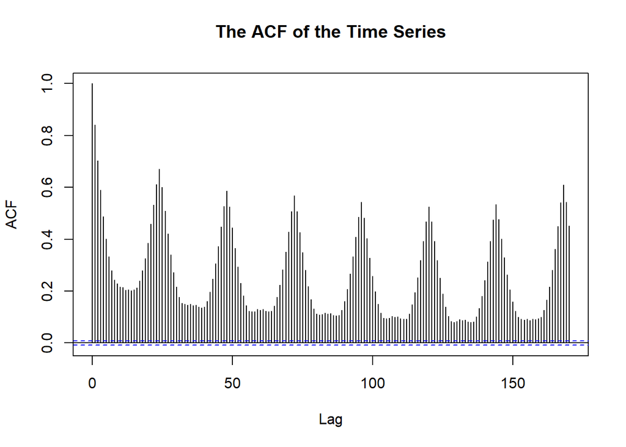

```r
acf(data[,mcp_dollars], lag.max = 170, main="The ACF of the Time Series")
```

## METHOD A: FORECASTING WITH TIME SERIES ANALYSIS

### Decomposing at Hourly Level

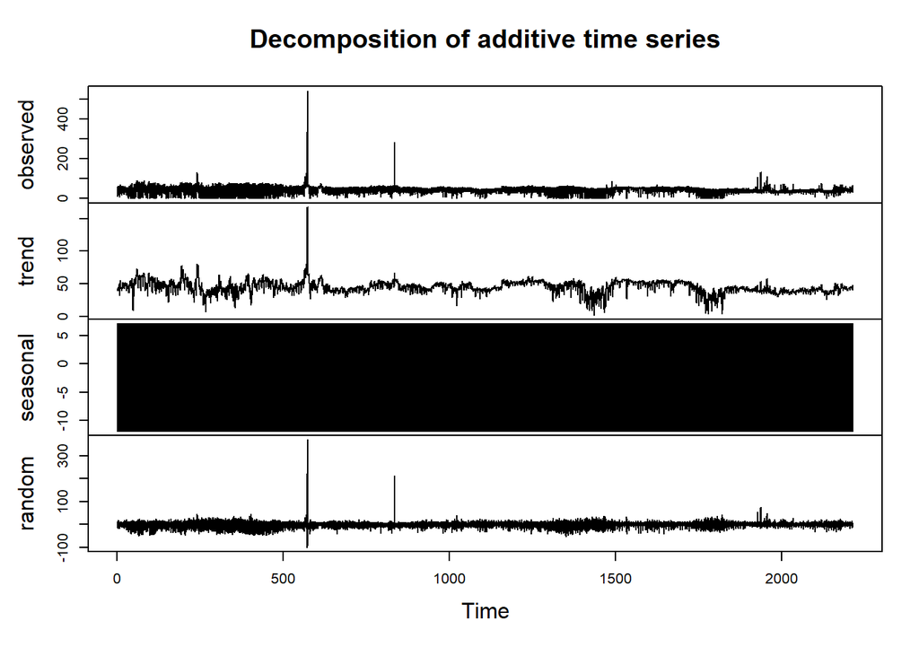

```r
data[,mcp_ts:=ts(mcp_dollars, freq=24)]
decomposed=data[,decompose(mcp_ts)]
plot(decomposed)
```

The trend curve is not smooth at all. It probably shows noises along with the general trend. Since the data is large seasonality effect is not easily seen. We can look at it more closely.

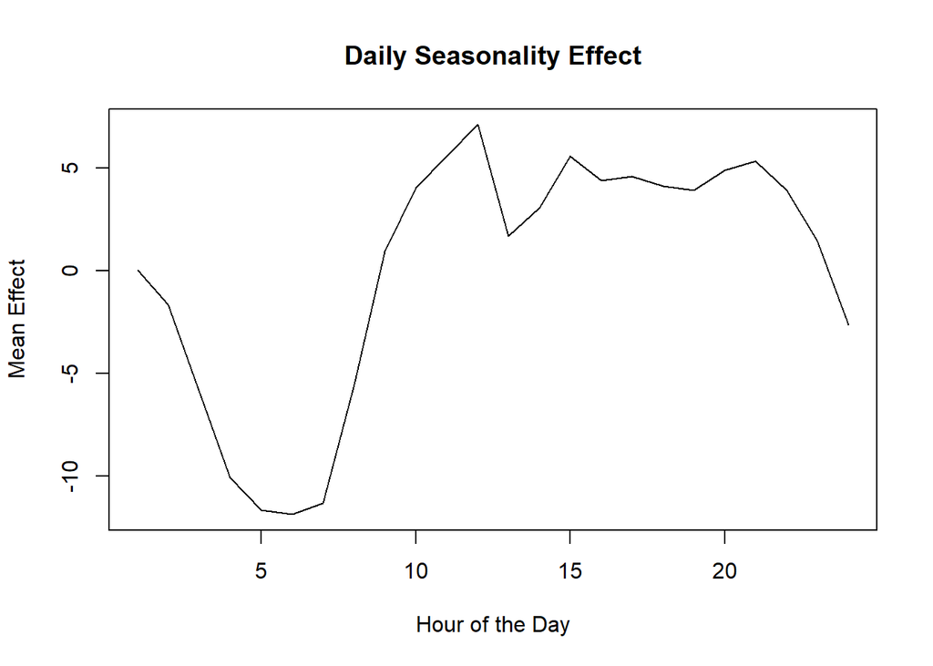

```r
ts.plot(decomposed$figure, xlab="Hour of the Day", ylab="Mean Effect", main="Daily Seasonality Effect")
```

MCP is lower in the mornings (around 5 am) and higher in noon and evening. It decreases at nights again.

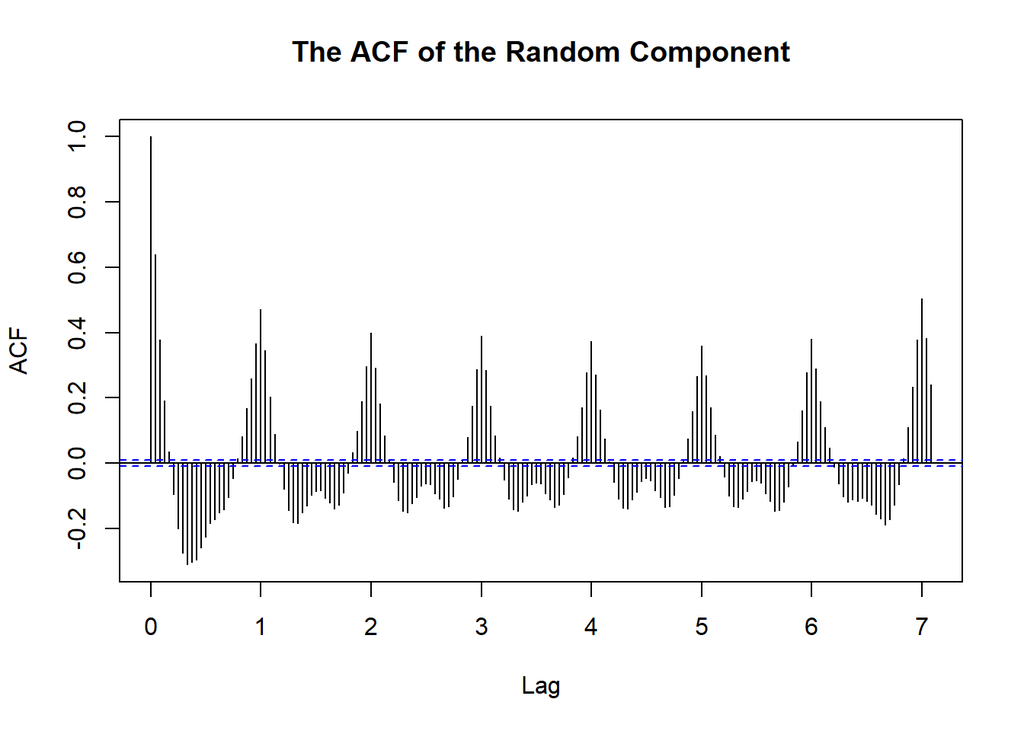

```r
acf(decomposed$random, na.action = na.pass, lag.max = 170, main="The ACF of the Random Component")
```

There are still significant autocorrelation in the series.

### Decomposing at Daily Level

```r
daily = data[, list(mcp=mean(mcp_dollars)), by=list(time=as.Date(time))]
trend = filter(daily[,mcp], sides = 2, filter = rep(1/7, 7))
daily = data.table(daily, trend)
```

Visually we have,

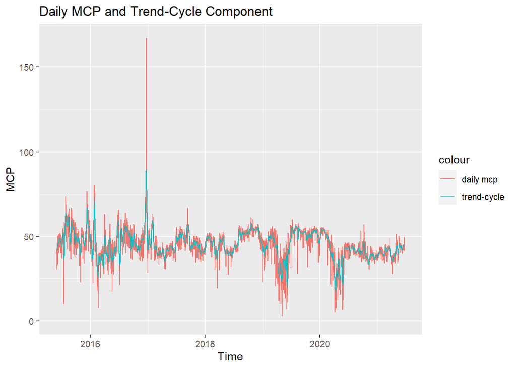

```r
ggplot(daily, aes(x = time)) +
  geom_line(aes(y=mcp, col="daily mcp")) +
  geom_line(aes(y=trend, col="trend-cycle")) +
  labs(title="Daily MCP and Trend-Cycle Component",
       x="Time",
       y="MCP")
```

The curve smooths the series better now, as expected. Now we can detrend the data and see the weekly seasonality effect.

```r
daily[,detrended:=mcp-trend]
daily[,seasonal:=mean(detrended, na.rm = TRUE), by=list(wday(time))]
```

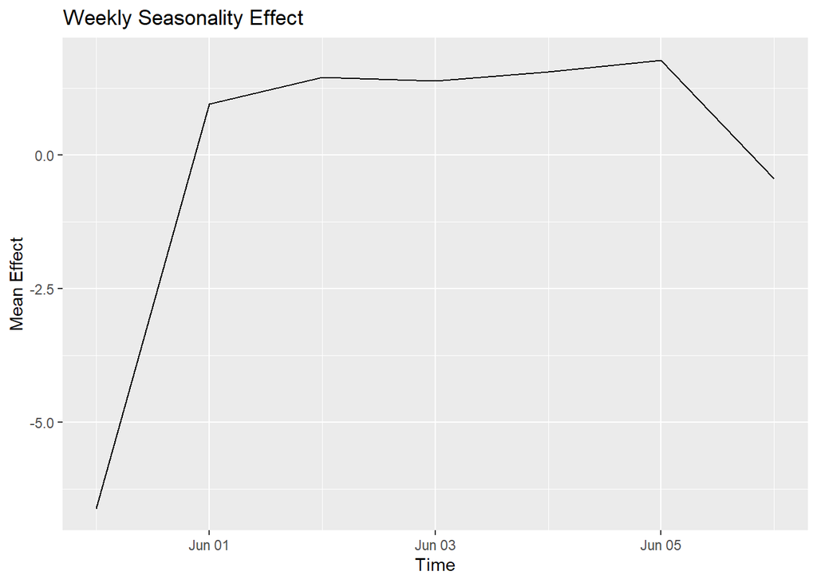

```r
ggplot(daily[1:7], aes(x=time, y=seasonal)) +
  geom_line() +
  labs(title="Weekly Seasonality Effect",
       x="Time",
       y="Mean Effect")
```

We see that prices are stable over the weekdays and are decreasing at the weekend, especially on Sunday.

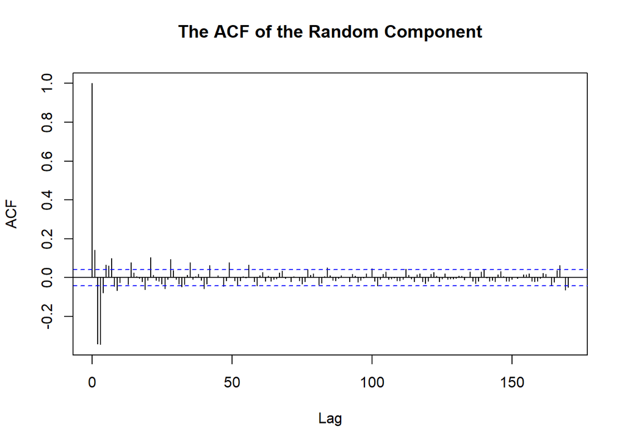

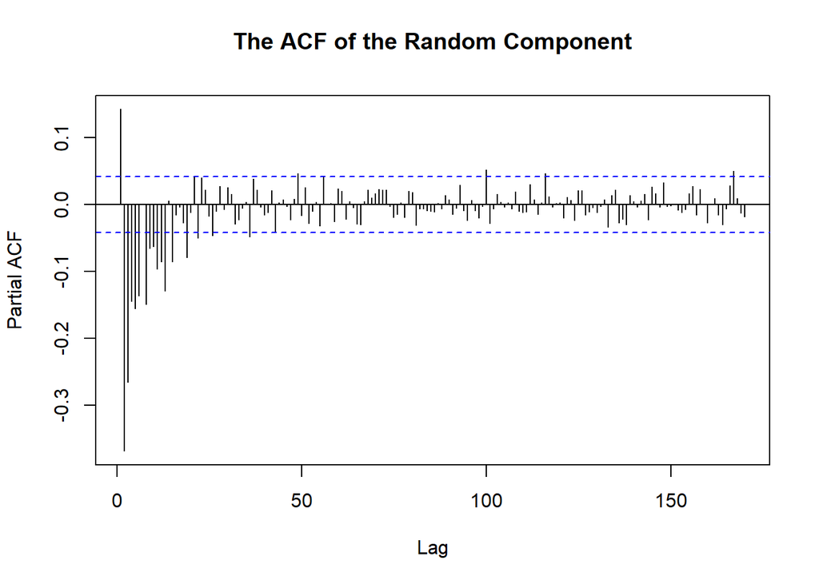

```r
daily[,random:=detrended-seasonal]
acf(daily[,random], na.action = na.pass, lag.max = 170, main="The ACF of the Random Component")
pacf(daily[,random], na.action = na.pass, lag.max = 170, main="The ACF of the Random Component")
```

The ACF improved somehow. There is only a few significant spikes.

### Decomposing at Weekly Level

The ACF of the daily decomposition is enough. Nevertheless, we can check other decomposition levels.

The weekly aggregation is not easy since every month has different number of weeks. If we assume there are 4 weeks in each month, we can have the effect of each week even if they are approximated numbers. Note that since the implementation of this decomposition is easier with decompose() function, we can use it instead of the previous method.

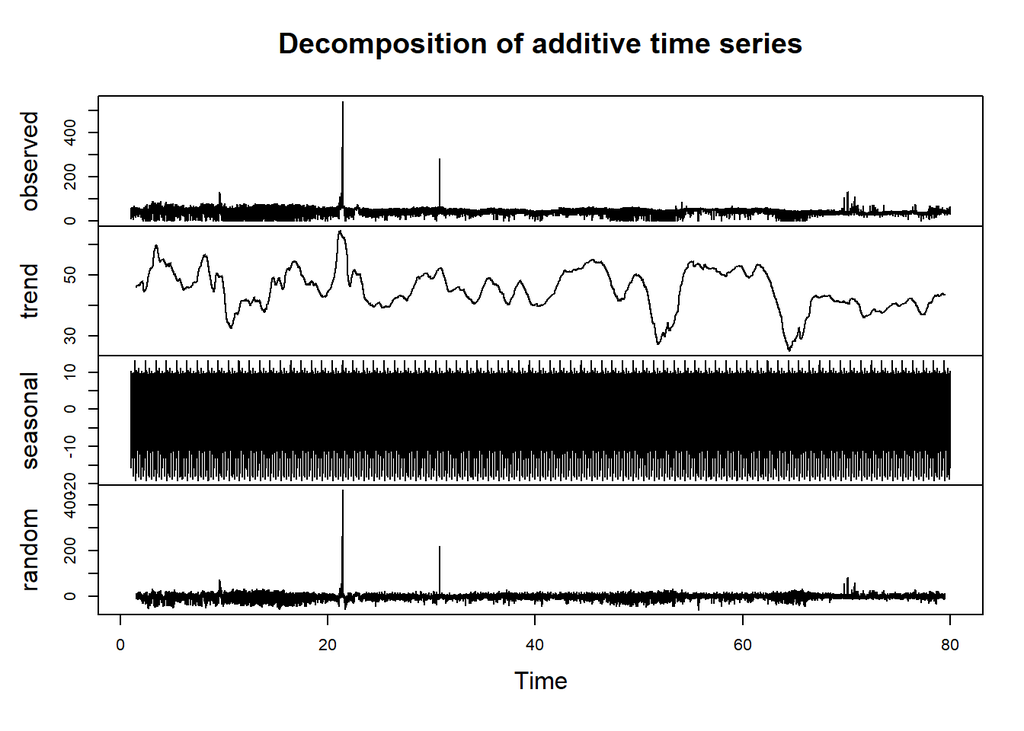

```r
data[,mcp_ts:=ts(mcp_dollars, freq=24*7*4)]  #24 hours/day -> 7 days/week -> 4 weeks/month
decomposed=data[,decompose(mcp_ts)]
plot(decomposed)
```

The trend curve smooths better. Since the data is large seasonality effect is not easily seen. We can look at it more closely.

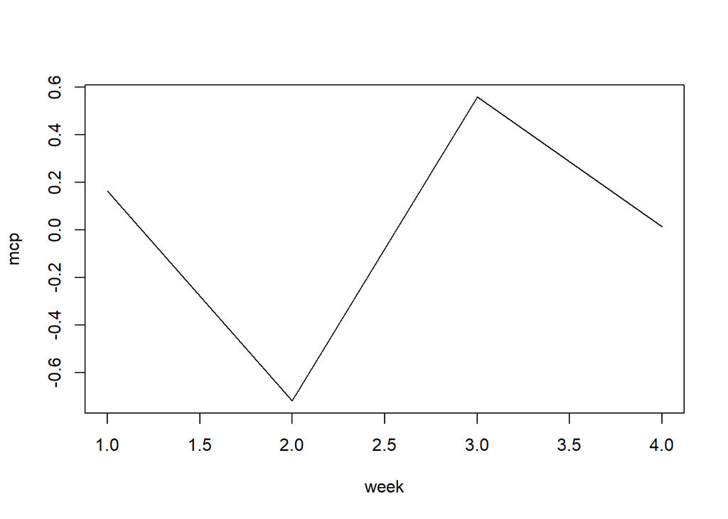

```r
seas=data.table(seas=decomposed$figure, t=1:672)
seas[,week:=floor(1+t/168)]
seas=seas[,.(mcp=mean(seas)), by=.(week=week)]
seas=seas[-5]
plot(seas, type="l")
```

It does not seem meaningful to decompose the series at weekly level. Mean effects are small anyways. Note that this is an approximation, the effects are not exact.

### Decomposing at Monthly Level

For decomposing the series at monthly level, we need daily mean consumption because we want to see the mean effect of each month. We need to manipulate the data to achieve this.

```r
monthly = daily[, list(mcp=mean(mcp, na.rm=TRUE)), by=list(month(time), year(time))]
months<-c("01","02","03","04","05","06","07","08","09","10","11","12")
monthly[, month := months[month]]
monthly[, dummy_day := "01"]
monthly[, time := as.Date(paste(year, month, dummy_day), format = "%Y %m %d")]
monthly[, c("month", "year", "dummy_day"):=NULL]
trend = filter(monthly[, mcp], sides = 2, filter = rep(1/12,12))
monthly = data.table(monthly, trend)
```

Now we have trend-cycle component and we can plot it.

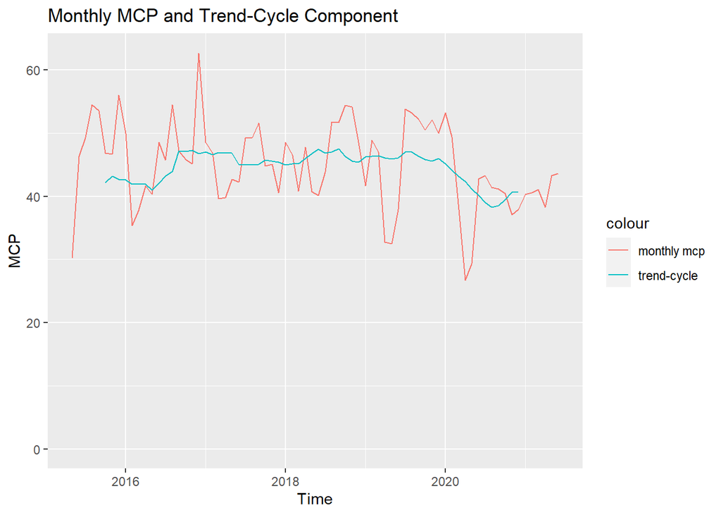

```r
ggplot(monthly, aes(x = time)) +
  geom_line(aes(y=mcp, col="monthly mcp")) +
  geom_line(aes(y=trend, col="trend-cycle")) +
  labs(title="Monthly MCP and Trend-Cycle Component",
       x="Time",
       y="MCP")
```

The level of smoothness is increased further. It only shows a general trend.

The following plot shows the seasonality effect.

```r
monthly[,detrended:=mcp-trend]
monthly[,seasonal:=mean(detrended, na.rm = TRUE), by=list(month(time))]
```

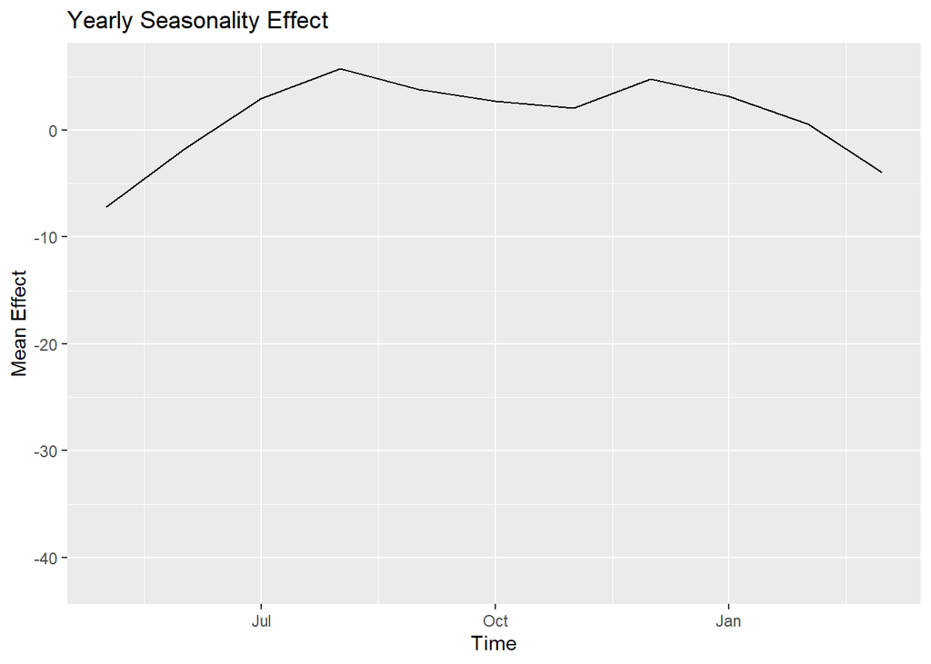

```r
ggplot(monthly[1:12], aes(x=time, y=seasonal)) + geom_line() +
  labs(title="Yearly Seasonality Effect",
       x="Time",
       y="Mean Effect")
```

We see that in the summer and the winter, prices are higher than those in the spring and the fall.

### Fitting a Model

Since the random component of the daily decomposition provides adequate ACF, we can move on with that decomposition.

From now on, we try to make forecasts for a specified time period. Therefore, the data is separated into test and training sets.

```r
train=data[time<"2021-05-22 00:00"]
test=data[time>="2021-05-22 00:00"]
```

```r
trend = filter(train[,mcp_dollars], sides = 2, filter = rep(1/168, 168))
train = data.table(train, trend)
```

There are several NAs in trend variable both in the head and in the tail of the data. Later, when we try to forecast the data, we will need trend values for all data points. In order to fill them, we can use `auto.arima()`. The order of the trend model is not important, so we only make forecast and skip this part instead of analyzing it.

```r
trend = train[!is.na(trend),trend]
trend = ts(trend, freq = 1)
m = auto.arima(trend, seasonal = F, stepwise = F, approx = F)
trend_forecast = forecast(m, h = 828)
trend_train = trend_forecast$mean[1:84]
trend_test = trend_forecast$mean[85:828]
train[(.N-83):.N, trend:=trend_train]
test[,trend:=trend_test]
```

We can now detrend the series in order to obtain seasonality effects. The following plot shows the seasonality effects of each individual season. Recall that the frequency is 168.

```r
train[, detrended:=mcp_dollars-trend]
train[, seasonal:=mean(detrended, na.rm = TRUE), by=list(wday(time),hour(time))]
```

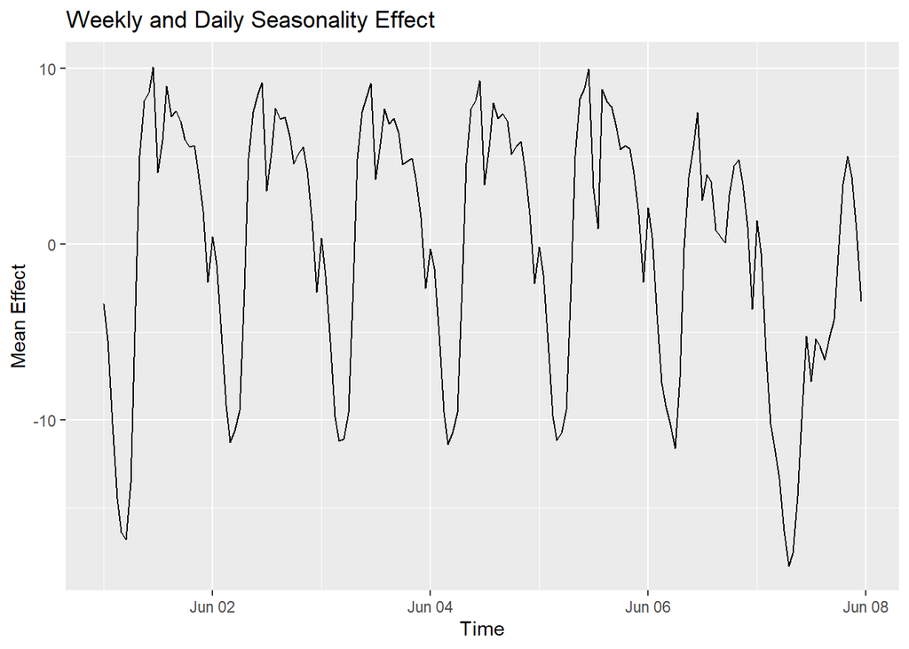

```r
ggplot(train[1:168], aes(x=time, y=seasonal)) + geom_line() +
  labs(title="Weekly and Daily Seasonality Effect",
       x="Time",
       y="Mean Effect")
```

Now we can obtain the random component and visually check it.

```r
train[, random:=detrended-seasonal]
```

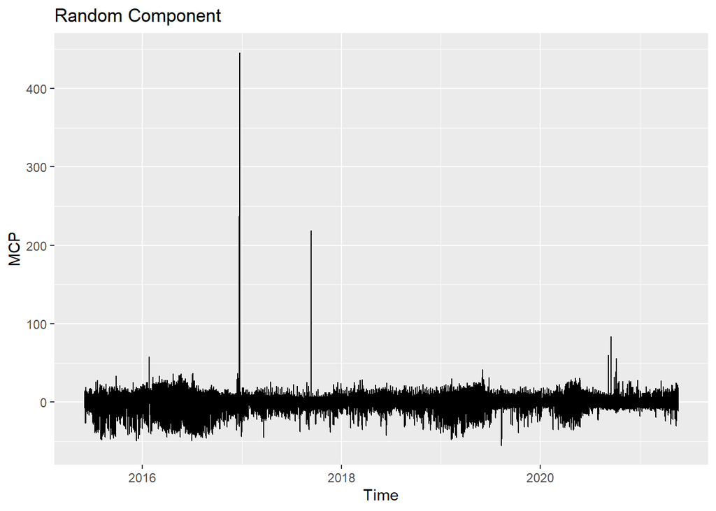

```r
ggplot(train, aes(x=time, y=random)) + geom_line() +
  labs(title="Random Component",
       x="Time",
       y="MCP")
```

Since we try to model the random component, we have to check its characteristics. We check its stationarity and then the ACF and the PACF.

```r
summary(ur.kpss(train[,random]))
```

```
##
## #######################
## # KPSS Unit Root Test #
## #######################
##
## Test is of type: mu with 19 lags.
##
## Value of test-statistic is: 6e-04
##
## Critical value for a significance level of:
##                 10pct  5pct 2.5pct  1pct
## critical values 0.347 0.463  0.574 0.739
```

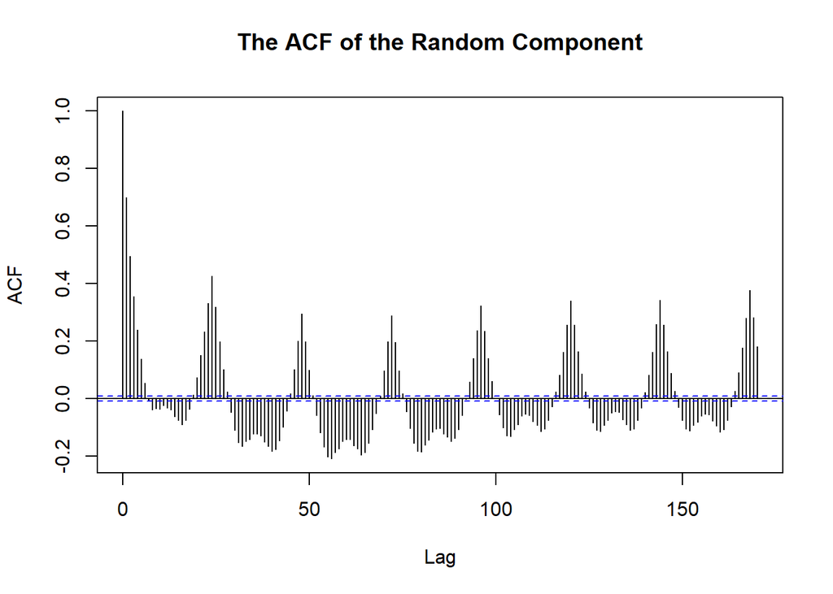

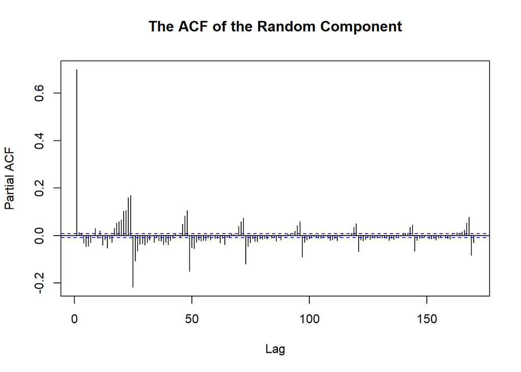

```r
acf(train[,random], na.action = na.pass, lag.max = 170, main="The ACF of the Random Component")
pacf(train[,random], na.action = na.pass, lag.max = 170, main="The ACF of the Random Component")
```

There is still significant autocorrelation at lag 24. We can take a seasonal difference and move on hoping that the seasonality effect vanishes because fitting a SARIMA model is too time consuming.

```r
train[,random_lag24:=shift(random,24)]
train[,diff_random:=random-random_lag24]
m1 = auto.arima(train[,diff_random], seasonal=F, stepwise=F, approx=F)
m1
```

```
## Series: train[, diff_random]
## ARIMA(1,0,2) with zero mean
##
## Coefficients:
##          ar1      ma1      ma2
##       0.8231  -0.2551  -0.0864
## s.e.  0.0048   0.0066   0.0056
##
## sigma^2 estimated as 60.11:  log likelihood=-181184.1
## AIC=362376.3   AICc=362376.3   BIC=362411.7
```

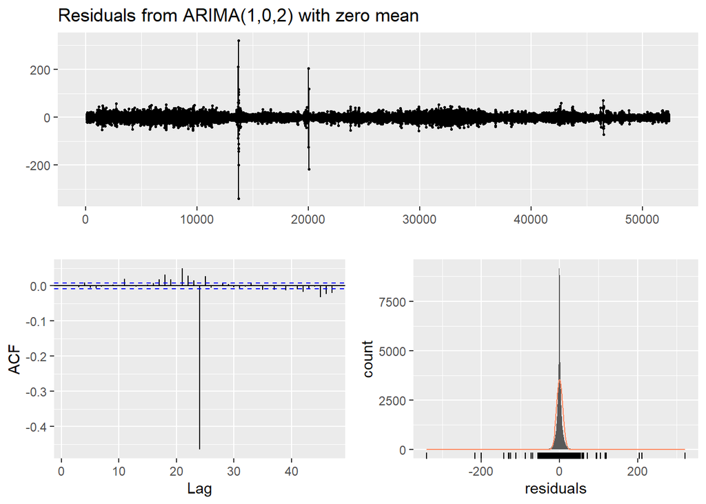

```
##
##  Ljung-Box test
##
## data:  Residuals from ARIMA(1,0,2) with zero mean
## Q* = 10.815, df = 7, p-value = 0.1469
##
## Model df: 3.   Total lags used: 10
```

```r
checkresiduals(m1)
```

Order of the ARIMA fitted to seasonal differenced random component is (1,0,2). Residuals look fine except a sifnificant spike at lag 24. But at this point there is nothing to do to fix it.

## METHOD B: FORECASTING WITH REGRESSION

Since we are going to use hour and the day for seasonality, we can add those to the data. This time we can also add month information since implementation is easy since we will fit linear models.

Note that we don’t need to use trend as a regressor because visually we can say that there is no linear relationship as we see earlier in the plot.

```r
train[,hour:=hour(time)]
test[,hour:=hour(time)]
train[,wday:=wday(time)]
test[,wday:=wday(time)]
train[,mon:=month(time)]
test[,mon:=month(time)]
```

We will add some regressors but we cannot use all of the variables. Some of them have flaws. For example, `biomass`, `naphta`, and `fuel_oil` are remain unchanged over time. They cannot explain MCP. We cannot use `other` either because we do not know what it is exactly. Therefore, using individual regressors may not be convenient. We may use another strategy.

```r
train[,renewable:=geothermal+dam+naphta+biomass+river]
test[,renewable:=geothermal+dam+naphta+biomass+river]
train[,lag_renewable:=shift(renewable,2)]
test[,lag_renewable:=shift(renewable,2)]
```

Now, let’s try to fit a linear model.

```r
m2_1=lm(mcp_dollars~lag_renewable+hour+wday+mon, data=train)
summary(m2_1)
```

```
##
## Call:
## lm(formula = mcp_dollars ~ lag_renewable + hour + wday + mon,
##     data = train)
##
## Residuals:
##    Min     1Q Median     3Q    Max
## -50.52  -7.23   1.00   8.30 490.29
##
## Coefficients:
##                Estimate Std. Error t value Pr(>|t|)
## (Intercept)   3.189e+01  2.513e-01  126.90   <2e-16 ***
## lag_renewable 2.234e-05  1.817e-05    1.23    0.219
## hour          5.142e-01  9.185e-03   55.99   <2e-16 ***
## wday          7.080e-01  3.007e-02   23.54   <2e-16 ***
## mon           6.733e-01  1.836e-02   36.67   <2e-16 ***
## ---
## Signif. codes:  0 '***' 0.001 '**' 0.01 '*' 0.05 '.' 0.1 ' ' 1
##
## Residual standard error: 13.73 on 52360 degrees of freedom
##   (2 observations deleted due to missingness)
## Multiple R-squared:  0.09665,    Adjusted R-squared:  0.09658
## F-statistic:  1400 on 4 and 52360 DF,  p-value: < 2.2e-16
```

Only the seasonality related variables are signficant and R-squared value is too small. We can try adding another regressor. We can add the ratio of the production by renewable energy sources to the total production.

```r
train[,ratio:=renewable/total_prod]
test[,ratio:=renewable/total_prod]
train[,lag_ratio:=shift(ratio,2)]
test[,lag_ratio:=shift(ratio,2)]
m2_2=lm(mcp_dollars~lag_ratio+hour+wday+mon, data=train)
summary(m2_2)
```

```
##
## Call:
## lm(formula = mcp_dollars ~ lag_ratio + hour + wday + mon, data = train)
##
## Residuals:
##    Min     1Q Median     3Q    Max
## -52.68  -7.44   0.75   8.33 493.53
##
## Coefficients:
##               Estimate Std. Error t value Pr(>|t|)
## (Intercept)  38.342719   0.268577  142.76   <2e-16 ***
## lag_ratio   -19.072558   0.546714  -34.89   <2e-16 ***
## hour          0.573978   0.008719   65.83   <2e-16 ***
## wday          0.701804   0.029677   23.65   <2e-16 ***
## mon           0.440933   0.018339   24.04   <2e-16 ***
## ---
## Signif. codes:  0 '***' 0.001 '**' 0.01 '*' 0.05 '.' 0.1 ' ' 1
##
## Residual standard error: 13.57 on 52360 degrees of freedom
##   (2 observations deleted due to missingness)
## Multiple R-squared:  0.1171, Adjusted R-squared:  0.1171
## F-statistic:  1737 on 4 and 52360 DF,  p-value: < 2.2e-16
```

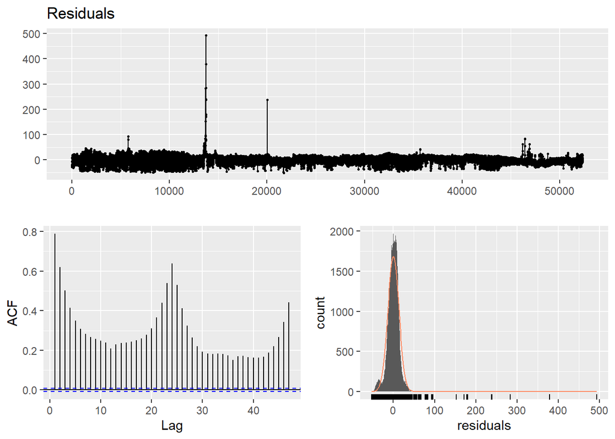

```
##
##  Breusch-Godfrey test for serial correlation of order up to 10
##
## data:  Residuals
## LM test = 32973, df = 10, p-value < 2.2e-16
```

```r
checkresiduals(m2_2)
```

```r
train[,lag_mcp:=shift(mcp_dollars,2)]
test[,lag_mcp:=shift(mcp_dollars,2)]
train[,lag24_mcp:=shift(mcp_dollars,24)]
test[,lag24_mcp:=shift(mcp_dollars,24)]
m2_3=lm(mcp_dollars~lag_mcp+lag24_mcp+lag_ratio+hour+wday+mon, data=train)
summary(m2_3)
```

```
##
## Call:
## lm(formula = mcp_dollars ~ lag_mcp + lag24_mcp + lag_ratio +
##     hour + wday + mon, data = train)
##
## Residuals:
##     Min      1Q  Median      3Q     Max
## -189.61   -3.36    0.33    3.36  343.32
##
## Coefficients:
##              Estimate Std. Error t value Pr(>|t|)
## (Intercept)  5.286052   0.217045  24.355  < 2e-16 ***
## lag_mcp      0.475092   0.003254 146.008  < 2e-16 ***
## lag24_mcp    0.404419   0.003265 123.852  < 2e-16 ***
## lag_ratio   -3.355994   0.364506  -9.207  < 2e-16 ***
## hour         0.059704   0.006053   9.863  < 2e-16 ***
## wday         0.046716   0.019658   2.376  0.01748 *
## mon          0.036991   0.012144   3.046  0.00232 **
## ---
## Signif. codes:  0 '***' 0.001 '**' 0.01 '*' 0.05 '.' 0.1 ' ' 1
##
## Residual standard error: 8.916 on 52336 degrees of freedom
##   (24 observations deleted due to missingness)
## Multiple R-squared:  0.6191, Adjusted R-squared:  0.619
## F-statistic: 1.417e+04 on 6 and 52336 DF,  p-value: < 2.2e-16
```

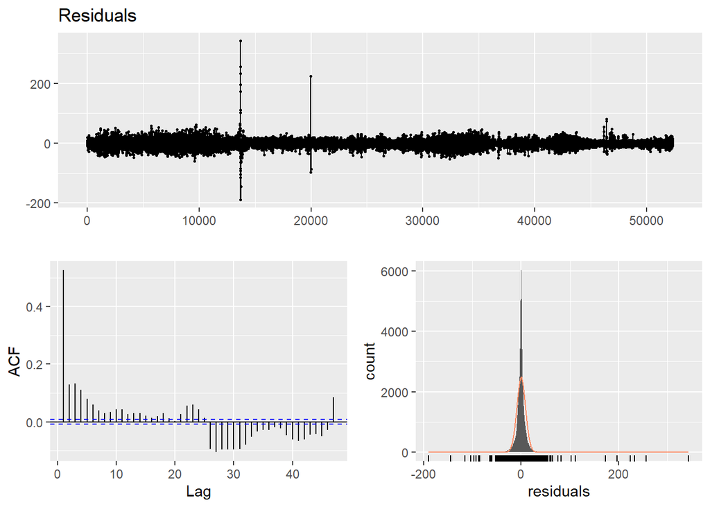

```
##
##  Breusch-Godfrey test for serial correlation of order up to 10
##
## data:  Residuals
## LM test = 19796, df = 10, p-value < 2.2e-16
```

```r
checkresiduals(m2_3)
```

## SELECTING THE BEST MODEL

We have to define a function. Note that this function is from the lectures.

```r
accu=function(actual,forecast, method){
  n=length(actual)
  error=actual-forecast
  mean=mean(actual)
  sd=sd(actual)
  CV=sd/mean
  FBias=sum(error)/sum(actual)
  MAPE=sum(abs(error/actual))/n
  RMSE=sqrt(sum(error^2)/n)
  MAD=sum(abs(error))/n
  MADP=sum(abs(error))/sum(abs(actual))
  WMAPE=MAD/mean
  l=data.frame(method,n,mean,sd,CV,FBias,MAPE,RMSE,MAD,MADP,WMAPE)
  return(l)
}
```

Now we can define a test period and compare two models.

```r
train_compare=train[time<"2021-04-21 23:00:00"]
test_compare=train[time>="2021-04-21 23:00:00"]
train_compare[,diff_random:=ts(diff_random,1)]

m1 = arima(train_compare[,diff_random], order=c(1,0,2))
m2 = lm(mcp_dollars~lag_mcp+lag24_mcp+lag_ratio+hour+wday+mon, data=train_compare)

arima_pred = forecast(m1, h=nrow(test_compare))
lm_pred = predict(m2, newdata=test_compare)

test_compare[,arima:=as.numeric(arima_pred$mean)+as.numeric(random_lag24)+
               as.numeric(trend)+as.numeric(seasonal)]
test_compare[,lm:=lm_pred]
```

Now we can compare two model using the function defined previously.

```r
test_compare[,rbind(accu(mcp_dollars,arima,"arima"),accu(mcp_dollars,lm,"lm"))]
```

```
##   method   n     mean       sd        CV         FBias      MAPE     RMSE
## 1  arima 721 42.44042 8.792811 0.2071801 -0.0025348195 0.1467181 8.526546
## 2     lm 721 42.44042 8.792811 0.2071801  0.0006713961 0.1148406 6.379462
##        MAD       MADP      WMAPE
## 1 5.634080 0.13275270 0.13275270
## 2 3.996765 0.09417355 0.09417355
```

We see that linear regression provides better results. Therefore, we can use it to make forecasts for the period between 2021-05-22 and 2021-06-21. First we need to define necessary variables.

```r
model=lm(mcp_dollars~lag_mcp+lag24_mcp+lag_ratio+hour+wday+mon, data=train)
test[1:2, lag_mcp:=train[(.N-1):.N, mcp_dollars]]
test[1:2, lag_ratio:=train[(.N-1):.N, ratio]]
test[1:24,lag24_mcp:=train[(.N-23):.N,mcp_dollars]]
test[,pred:=predict(model,newdata=test)]
```

We can plot the forecasted values.

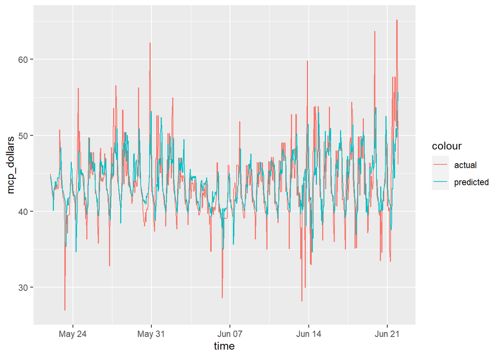

```r
ggplot(test, aes(x=time)) +
  geom_line(aes(y=mcp_dollars, col="actual")) +
  geom_line(aes(y=pred, col="predicted"))
```

```r
test[,accu(mcp_dollars,pred,"lm")]
```

```
##   method   n     mean       sd        CV        FBias       MAPE     RMSE
## 1     lm 744 43.71305 4.553096 0.1041587 -0.005260346 0.05237591 3.403778
##        MAD       MADP      WMAPE
## 1 2.301889 0.05265909 0.05265909
```

# CONCLUSION

In conclusion, we first tried to understand the characteristics of the series by decomposing at different levels. Then we tried to fit a model on random component of the decomposition at frequency of 168. The linear regression method, however, provides better results therefore it is used to make forecasts. The final model performs good enough on the test data as it seen in the above performance measures.